# 03_Merge05_09

Calen P. Ryan

30 November, 2018

Originally written November 15th or so, 2018

> This document merges and explores the 2005, 2007, and 2009 data.

# Setup

## Setup: Options

```r
knitr::opts_chunk$set(tidy = TRUE)
```

## Setup: Packages - messages hidden

```r
library(tidyverse)  # The tidyverse, baby
library(haven)  # Used to load different datatypes, like .dat
library(readr)  # Also used to read different data types
library(lubridate)  # Working with dates
library(expss)  #
library(sjlabelled)
library(vcd)  ## used for estimating goodness of fit for poisson distribution
library(here)
```

# Load Data

## Load DNAm data, blooddraw data with icsex

```r
# Load dnam individuals

dnam <- read_csv(here::here("Data/Other", "uncchdid_w_DNAm.csv"))
names(dnam) <- "uncchdid"
# Remove the _R1 and _R2
dnam$uncchdid <- substr(dnam$uncchdid, 1, 5)
dim(dnam)


# LOad the blood draw dates, which has the sex. Merge and keep sex for DNAm

blood.draw.dates <- read_csv(here("Data/Other", "blood.draw.dates.csv"))[, -1]
blood.draw.dates$uncchdid <- as.character(blood.draw.dates$uncchdid)


chk.bld.draw <- left_join(dnam, blood.draw.dates, by = "uncchdid")

dnam.f <- chk.bld.draw %>% filter(icsex == "0=female")
```

## Load 2005 Data

> Before and after including only women with DNAm data

```r
preg05 <- read_dta(here("Data/2005/", "PREGHIST.dta"))

dim(preg05)
```

```
## [1] 531 104
```

```r
preg05$uncchdid <- as.character(preg05$uncchdid)
preg.dnam05 <- left_join(dnam.f, preg05, by = "uncchdid")

dim(preg.dnam05)
```

```
## [1] 515 109
```

## Load 2007 Data

> Before and after including only women with DNAm data

```r
preg07 <- read_dta(here("Data/2007/Statafiles/", "PREGHIST.dta"))

dim(preg07)
```

```
## [1] 901  85
```

```r
preg07$uncchdid <- as.character(preg07$uncchdid)
preg.dnam07 <- left_join(dnam.f, preg07, by = "uncchdid")

dim(preg.dnam07)
```

```
## [1] 649  90
```

## Load 2009 Data

> Before and after including only women with DNAm data

```r
preg09 <- read_dta(here("Data/2009/Statafiles/", "PREGHIST.dta"))

dim(preg09)
```

```
## [1] 1116   78
```

```r
preg09$uncchdid <- as.character(preg09$uncchdid)
preg.dnam09 <- left_join(dnam.f, preg09, by = "uncchdid")

dim(preg.dnam09)
```

```
## [1] 766  83
```

```r
labels <- lapply(preg09, attr, "label")
str(labels, list.len = ncol(preg09))
```

```
## List of 78
##  $ basebrgy : chr "BASELINE BARANGAY ID NUMBER"
##  $ basehhno : chr "BASELINE HOUSEHOLD ID NUMBER"
##  $ basewman : chr "BASELINE SAMPLE WOMAN ID NUMBER"
##  $ uncchdid : NULL
##  $ uncmomid : chr "MOTHER'S ID NUMBER"
##  $ icsex    : chr "SEX OF INDEX CHILD"
##  $ pregord  : chr "PREGNANCY ORDER"
##  $ pregterm : chr "TYPE OF PREGNANCY TERMINATION"
##  $ monthprg : chr "MONTH OF BIRTH OR PREGNANCY TERMINATION"
##  $ dayprg   : chr "DAY OF BIRTH  OR PREGNANCY TERMINATION"
##  $ yearprg  : chr "YEAR OF BIRTH OR PREGNANCY TERMINATION"
##  $ durmonth : chr "NUMBER OF MONTHS INDEX CHILD WAS PREGNANT"
##  $ durdays  : chr "NUMBER OF DAYS SINCE INDEX CHILD'S LAST MENSTRUATION (if not sure if pregnant)"
##  $ prenatal : chr "DID INDEX CHILD GET PRENATAL CARE DURING THIS PREGNANCY?"
```

[output cut: 64 more lines]

## Load 2014

> Before and after including only women with DNAm data

```r
preg14 <- read_dta(here("Data/2009_2014/Birth/corrected Stata files/", "birthinfo_20141016.dta"))

dim(preg14)
```

```
## [1] 502  93
```

```r
# Extract the women with blood draw at T1
preg14$uncchdid <- as.character(preg14$uncchdid)

preg.dnam14 <- left_join(dnam.f, preg14, by = "uncchdid")
#
length(unique(preg.dnam14$uncchdid))
```

```
## [1] 395
```

### Check 2014 variables (to include change eval = T)

```r
labels <- lapply(preg14, attr, "label")
str(labels, list.len = ncol(preg14))
```

# Merge 2005, 2007, 2009

> Create one file which I can then remove the duplicates and generate a tally of pregancies.

rbind will only work where names intersect. Pick variables using intersect and bind the rows.

## Overlapping variables for 2007, 2009

```r
intersect(names(preg07), names(preg09))
```

```
##  [1] "basebrgy" "basehhno" "basewman" "uncchdid" "uncmomid" "pregord"
##  [7] "pregterm" "monthprg" "dayprg"   "yearprg"  "durmonth" "durdays"
## [13] "prenatal" "moprenat" "wherpren" "xtba"     "xgovper"  "xpvtper"
## [19] "vitamins" "vitamin1" "vitamin2" "injectio" "injectn1" "injectn2"
## [25] "wherborn" "assist"   "typedelv" "complica" "complic1" "complic2"
## [31] "anesthes" "weighed"  "wherweig" "whoweigh" "weightma" "weighrec"
## [37] "monweigh" "dayweigh" "yrweigh"  "assumewt" "borntime" "monthdie"
## [43] "daydie"   "yeardie"  "causedie" "breastfd" "notbf1"   "notbf2"
## [49] "hrs1stbf" "stillbf"  "whynobf1" "whynobf2" "daysbf"   "mlksuple"
## [55] "mlksupp1" "mlksupp2" "oldmilk"  "solidfod" "oldsolid" "endpreg"
## [61] "whoend"   "whatdone" "married"  "longfp"   "pregwork" "pregwor1"
## [67] "pregwor2" "workaftr" "workaft1" "workaft2"
```

> 2007 and 2009 have much in common Same for 2005, 2007, and 2009, so these will merge just fine.

## What variables overlap for 2007/2009, and 2009-14

```r
intersect(intersect(names(preg07), names(preg09)), names(preg14))
```

```
##  [1] "basebrgy" "basehhno" "basewman" "uncchdid" "uncmomid" "monthprg"
##  [7] "dayprg"   "yearprg"  "complica" "weighed"  "monthdie" "daydie"
## [13] "yeardie"  "causedie"
```

2007/2009 and 2009-2014 (NSF) do not.

> Merge 2005, 07, and 09.  
> Chris probably already did this with 050709mergedibi.dta but I’ll redo Use as a base for other (NSF) data.

## Pick the overlap variables - NOT INCLUDED ARE…

```r
all.in <- intersect(intersect(names(preg05), names(preg07)), names(preg09))

setdiff(setdiff(names(preg05), names(preg07)), names(preg09))
```

```
##  [1] "brgay05"  "hhnumb05" "woman05"  "momch05"  "linenumb" "age"
##  [7] "sex"      "maristat" "gradecom" "worknow"  "monpregh" "daypregh"
## [13] "yrpreghi" "who1inje" "who2inje" "injectn3" "who3inje" "father"
## [19] "choreprg" "choreaft" "lineicc"
```

## preg579 = 2005,2007 and 2009 from the overlap in variables

```r
preg579 <- rbind(preg05[, all.in], preg07[, all.in], preg09[, all.in])
```

## Include only women with DNAm

```r
preg579.dnam <- left_join(dnam.f, preg579, by = "uncchdid")

# View(preg579.dnam)
```

## Remove duplicate children (counted in 2005 and 2009, etc.)

```r
preg579.nodup <- preg579.dnam[!duplicated(preg579.dnam[c("uncchdid", "pregord")]),
    ]
```

### How many women are NA for all pregord (parity = 0)

```r
# Call anyone from DNAm file with NA, 0 to count them moving forward.
preg579.nodup$pregord <- preg579.nodup$pregord %>% replace_na(0)
```

### Breakdown of number of pregnancies up to 2009 + histogram

```r
# Table breakdown
preg579.nodup %>% group_by(uncchdid) %>% summarize(max.preg = max(pregord)) %>%
    count(max.preg)
```

```
## # A tibble: 9 x 2
##   max.preg     n
##      <dbl> <int>
## 1        0    70
## 2        1   128
## 3        2    98
## 4        3    56
## 5        4    28
## 6        5     8
## 7        6     4
## 8        7     2
## 9        8     1
```

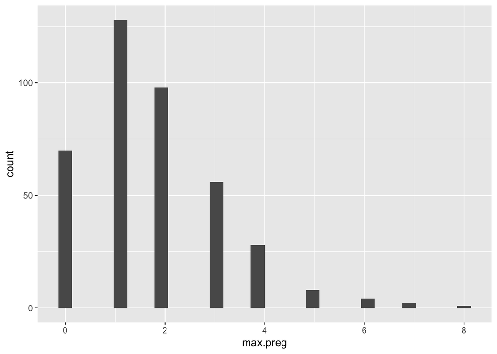

```r
# Histogram of the pregnancy data
preg579.nodup %>% group_by(uncchdid) %>% summarize(max.preg = max(pregord)) %>%
    ggplot(aes(x = max.preg)) + geom_histogram()
```

> Is there is anyone for whom pregnancies were counted twice?  
> Happens if women have -9 for a pregnancy (say in 2005), and then the same pregnancy is counted but given a date in 2007/2009

### Are there any more double-counted pregnancies?

```r
# Female has to have >1 pregnancy.  Female has to have one of them be -9
# (unknown) One of the observations should be 'still pregnant' Other
# conditions?


# Wait - if I check pregord and look for duplicates...  Which are duplicated
# (first down and last up) for BOTH uncchdid and pregord.
nrow(preg579.nodup[(duplicated(preg579.nodup[c("uncchdid", "pregord")]) | duplicated(preg579.nodup[c("uncchdid",
    "pregord")], fromLast = TRUE)), ])
```

```
## [1] 0
```

> Noone has duplicated pregord - no pregnancies were counted for >1